```python
%%javascript
IPython.OutputArea.prototype._should_scroll = function(lines) {
    return false;
}
```

```python
# to load images for this tutorial
from IPython.display import Image
import os
path = os.getcwd()

# Math libraries
import numpy as np
import matplotlib.pyplot as plt
```

# Post Goals

1. Provide an Introduction to Logistic Regression.
2. Demonstrate How Logistic Regression Estimates Probabilities.
3. Discuss Training and Cost Function.
4. Demonstrate how to conduct Logistic Regression using Python Sklearn.
5. Demonstrate how to use Decision Boundaries in Logistic Regressions.

# **Part 1: Provide an Introduction to Logistic Regression.**

- Logistic regression is regression algorithm that can be used for classification problems.
- Logistic regression is also known as *Logit Regression*
- There are three major types of logistic regression:
  - *Binomial Logistic Regression*: there are only two possible outcomes (yes/no, cat 1 or cat 2).
  - *Multinomial Logistic Regression*: there are three or more possible outcomes without order. Example: planet, start, comet
  - *Ordinal Logistic Regression*: there are three or more possible outcomes with ordering. Example: movie ratings from boring, okay, good, great.
- The focus of this post is the binomial logistic regression
- Binomial Logistic regression is used to explain the relationship between a dependent binary variable and one or more continuous or categorical data (nominal, ordinal, interval, or ratio-level) independent variables.
- **In other words:** Binomial Logistic regression is used to estimate the probability that an instance belongs to a specific class. Does the observation fall into one of two categories?
- A decision boundary is used to set a threshold for prediction making. For binary classification, if an instance is less than 50%, it is classified in one category, and if is greater or equal to 50%, it is classified in the 2nd cagetory.
- Decision boundaries can be linear or non-linear. Polynomial order can be increased to get a more complex decision boundary
- Example of logistic regression problems:
  - What is the probability that email is spam? (spam/ not spam)
  - What is the probability that transaction is fraud? (yes/no)
  - What is the probability that this tissue sample is cancerous? (yes/no)
- Instances greater than 50% are labeled positive class, "1" .
- Instances less than 50% are labeled negative class, "0".
- **Major Assumptions**
1. Dependent variable should be dichotomous in nature (yes/no, present/absent, male/female etc). If your dependent variable is continuous, you need to carry out a multiple regression analysis instead. If the dependent variable is measu  
   red on an ordinal scale, use an ordinal regression.
2. Data should have no outliers in the data. To omit outlier data, the continuous predictor data should be converted to standarized scores, and values below -3.29 and greater than 3.29 should be removed.
3. You have one or more independent variables which can be either continuous (interval, ratio), or categorical (ordinal, nominal).
4. No high association between independent variables. A correlation matrix should be used among predictors and if the long correlation coefficients among independent variables are less than 0.90, then those features are okay, otherwise omit.
5. Independent observations and dependent variables should have mutually exclusive and exhaustive categories.
6. There needs to be a linear relationship between any of the continous independent variables and the logit transformation of the dependent variable. The Box-Tidwell (1967) procedure can be used to test for linearity.

# **Part 2: Demonstrate How Logistic Regression Estimates Probabilities.**

- Logistic regression models compute a weighted sum for all the features and adds a bias term.
- Unlike linear regression models that then output the result directly, logistic regression outputs the *logistic* of the result.
- Equation 1: The vectorized form for the model estimated probability can be viewed below.
- Equation 2: The logistic model is a sigmoid function that outputs a number between 0 and 1. Sigmoid Function
- Once the probability of p̂ has been estimated that an instance of **x** belongs to the positive class, then a prediction can be made using the Logistic Regression Model Precition Equation.
- Note on Logistic Function:
  - When σ(*t*) < 0.5, Then *t* < 0  
    And p̂ is 0 when *t* is negative.
  - When σ(*t*) >= 0.5, Then *t* >= 0  
    And p̂ is 1 when *t* positive.
- The *t* score is called the *logit* because it is the inverse of the logistic function.
- You will get *t* if you compute the logit of the estimated probability *p*.
- The logit is the log of the ratio between the estimated probability for the positive class and the estimated probability for the negative class. Because of this, it is also called the *log-odds*

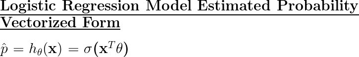

```python
img = os.path.join(path, 'static/images/log_reg_est_prob_vec_form.png')
Image(filename=img)
```

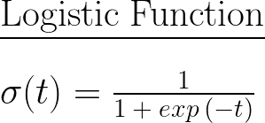

```python
# to load images
img = os.path.join(path, 'static/images/logistic_function_equation.png')
Image(filename=img)
```

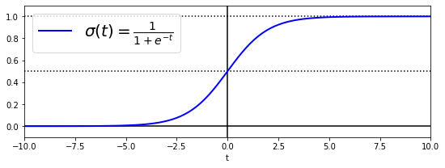

```python
# visualize a sigmoid function
t = np.linspace(-10, 10, 100) # Return evenly spaced numbers over a specified interval.
sig = 1 / (1 + np.exp(-t)) # the sigmoid function
plt.figure(figsize=(9, 3)) # instantiates a figure object
plt.plot([-10, 10], [0, 0], "k-") # adds line
plt.plot([-10, 10], [0.5, 0.5], "k:") # adds line
plt.plot([-10, 10], [1, 1], "k:") # adds line
plt.plot([0, 0], [-1.1, 1.1], "k-") # adds line

# plot the sigmoid function
plt.plot(t, sig, "b-", linewidth=2, label=r"$\sigma(t) = \frac{1}{1 + e^{-t}}$")
plt.xlabel("t") # x axis label
plt.legend(loc="upper left", fontsize=20) # adds legend
plt.axis([-10, 10, -0.1, 1.1]) #sets the axis boundaries
#save_fig("logistic_function_plot")
plt.show()
```

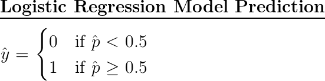

```python
# to load images
img = os.path.join(path, 'static/images/logreg_model_prediction.png')
Image(filename=img)
```

# **Part 3: Discuss Training and Cost Function.**

- The objective of training is to set the parameter vector θ so that the model estimates high probabilities for instances that are positive y=1, and low probabilities for instances that are negative (y=0).
- Equation: Cost function of a single training instance. This equations demonstrates the cost function during training of a single instance.
- - When *t* < 0  
    -log(t) grows very large  
    Then the cost function will be large if the model estimates a probability close to 0 for **positive instances** and when the model estimates a probability close to 1 for **negative instances**.
  - When *t* is close to **1**  
    -log(t) approaches **0**  
    if the estimates probability is close to **0** for **negative instances** or close to 1 for **positive instances**.
- Equation: Log Loss, Logistic Regression Cost Function The cost function for the whole traning set is the average cost for each instance.
- The cost function is convex and Gradient Descent is guranteed to find the global minimum.
- Equation: Logistic cost function partial derivatives for each instance the predicted error is multiplied by the jth feature value, and it then computes the average over the entire training set.
- The gradient vector can then be used on Gradient Descent.

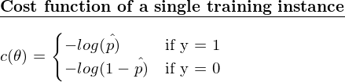

```python
# to load images
img = os.path.join(path, 'static/images/cost_func_sng_t_ins.png')
Image(filename=img)
```

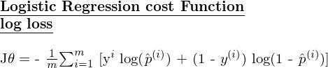

```python
# to load images
img = os.path.join(path, 'static/images/logreg_cost_function.png')
Image(filename=img)
```

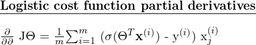

```python
# to load images
img = os.path.join(path, 'static/images/log_costfunc_part_der.png')
Image(filename=img)
```